# Autocorrelação espacial

#### 5. Observando o filtro ambiental no espaço geográfico

Uma vez que nossos dados foram selecionados independentemente do espaço geográfico, podemos ver como eles se comportam.  
Vamos plotar o objeto `occ.env.filtered`:

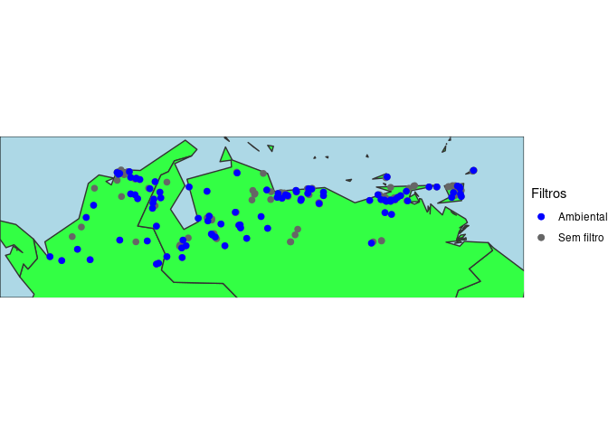

```r
base<- ggplot()+
  geom_polygon(data = shape_df , aes(x = long, y = lat, group = group), fill = '#33FF44', color = '#333333')+
  theme_void()+
  theme(panel.background = element_rect('light blue'))+
  coord_equal(xlim=ext[1:2], ylim=ext[3:4])

colors<-c("Sem filtro"="grey40","Ambiental"="blue", "Geográfico"="red")

base+
geom_point(data = occ, aes(x = LONG, y = LAT, col="Sem filtro"), size=2)+
geom_point(data = occ.env.filtered, aes(x = LONG, y = LAT, col="Ambiental"), size=2)+
  scale_color_manual(values=colors, name="Filtros")
```

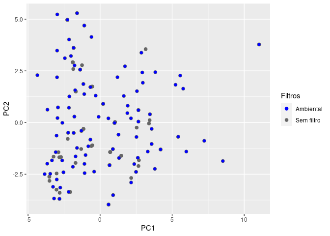

```r
ggplot()+
  geom_point(data=espacoAmbiental, aes(PC1, PC2, col="Sem filtro"), size=2)+
  geom_point(data=env.filtered[[1]], aes(PC1, PC2, col="Ambiental"))+
  scale_color_manual(values=colors, name="Filtros")
```

```r
#geom_point(data = thinned_data[[1]], aes(x = Longitude, y = Latitude), color=rgb(1,0,0,0.3), cex=2)+
```

Por fim, podemos comparar filtros distintos. Primeiro no espaço geográfico:

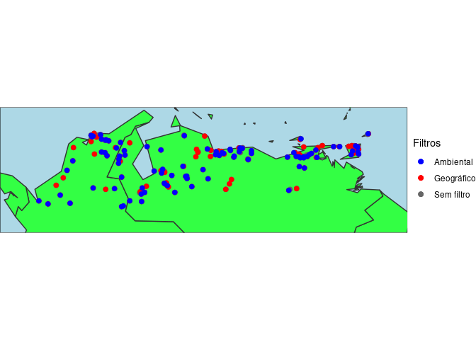

```r
#Plot geral
base+
  geom_point(data = occ, aes(x = LONG, y = LAT, col="Sem filtro"), size=2)+
  geom_point(data = thinned_data[[1]],
             aes(x = Longitude, y = Latitude, col="Geográfico"), cex=2)+
  geom_point(data = occ.env.filtered,
             aes(x = LONG, y = LAT, col="Ambiental"), size=2)+
  scale_color_manual(values=colors, name="Filtros")
```

Vemos uma boa disperssão dos dois filtros. Como há vários pontos sobrepostos para ambos, vamos ver mais de perto:

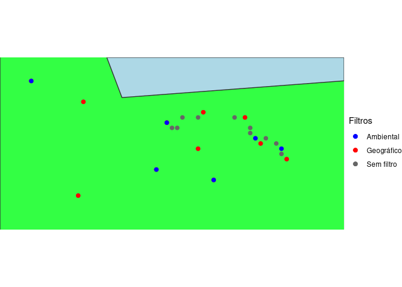

```r
#Plot de um zoom
base+
  geom_point(data = occ, aes(x = LONG, y = LAT, col="Sem filtro"), size=2)+
  geom_point(data = thinned_data[[1]],
             aes(x = Longitude, y = Latitude, col="Geográfico"), cex=2)+
  geom_point(data = occ.env.filtered,
             aes(x = LONG, y = LAT, col="Ambiental"), size=2)+
  scale_color_manual(values=colors, name="Filtros")+
  coord_equal(xlim=c(-68.5,-67.5), ylim=c(10.1,10.6))
```

Aqui vemos como os dois métodos selecionaram de modo distintos os ambientes. Neste quadro, as duas abordagens parecem ter amostrado bem o espaço geográfico.

Vamos checar os filtros no Espaço Ambiental:

```r
#Plot do espaço ambiental e seus filtros
ggplot()+
  geom_point(data=espacoAmbiental, aes(PC1, PC2, col="Sem filtro"))+
  geom_point(data=env.filtered[[1]], aes(PC1, PC2, col="Ambiental"))+
  geom_point(data=espacoAmbiental[row.names(thinned_data[[1]]),], aes(PC1, PC2, col="Geográfico"))+
  scale_color_manual(values=colors, name="Filtros")
```

[output not shown]